# Body size of reef fish decrease along with latitude descending

#### Geographical Mapping and Visualization

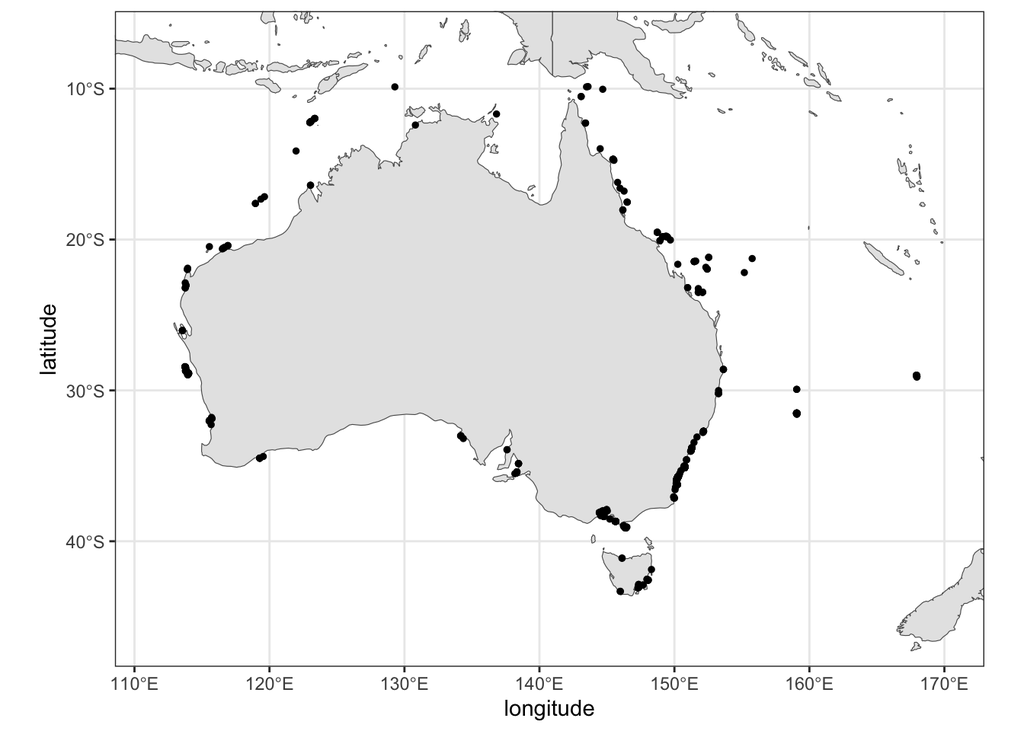

#### Scatter Plots

To look into the relationship between latitudinal distribution and size class, scatter plots were employed. Each point on the scatter plots represented an observation of a specific reef fish species, with latitude on the x-axis and size class on the y-axis. Contrary to our initial expectations, the scatter plots did not reveal a clear and consistent pattern of size class variation based on latitudinal distribution. Instead, the data points exhibited considerable variability, suggesting the need for further statistical analysis.

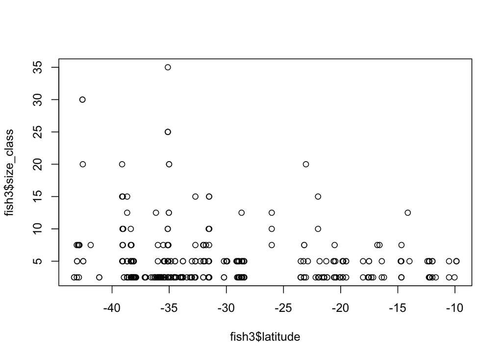

#### Linear Regression Models

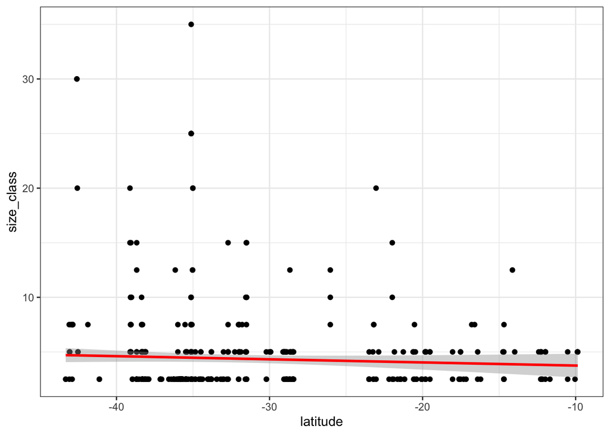

```r
model1 <- lm(fish3$size_class ~ fish3$latitude)
summary(model1)
```

```
##
## Call:
## lm(formula = fish3$size_class ~ fish3$latitude)
##
## Residuals:
##     Min      1Q  Median      3Q     Max
## -2.2055 -1.9893 -1.7905  0.6733 30.5297
##
## Coefficients:
##                Estimate Std. Error t value Pr(>|t|)
## (Intercept)     3.46322    0.77948   4.443 1.09e-05 ***
## fish3$latitude -0.02868    0.02376  -1.207    0.228
## ---
## Signif. codes:  0 '***' 0.001 '**' 0.01 '*' 0.05 '.' 0.1 ' ' 1
##
## Residual standard error: 4.046 on 505 degrees of freedom
## Multiple R-squared:  0.002876,   Adjusted R-squared:  0.0009019
## F-statistic: 1.457 on 1 and 505 DF,  p-value: 0.228
```

```r
model2 <- lm(fish3$size_class ~ fish3$species_name)
summary(model2)
```

```
##
## Call:
## lm(formula = fish3$size_class ~ fish3$species_name)
##
## Residuals:
##     Min      1Q  Median      3Q     Max
## -2.0703 -2.0588 -1.6797  0.8203 30.4412
##
## Coefficients:
##                                     Estimate Std. Error t value Pr(>|t|)
## (Intercept)                          4.55882    0.26296  17.336   <2e-16 ***
## fish3$species_nameAtherinidae spp.  -0.80882    0.74377  -1.087    0.277
## fish3$species_nameClupeidae spp.    -0.37914    0.44466  -0.853    0.394
## fish3$species_nameClupeiformes spp.  0.01149    0.57122   0.020    0.984
## fish3$species_nameGobiidae spp.     -0.37278    0.67222  -0.555    0.579
## ---
## Signif. codes:  0 '***' 0.001 '**' 0.01 '*' 0.05 '.' 0.1 ' ' 1
##
## Residual standard error: 4.057 on 502 degrees of freedom
## Multiple R-squared:  0.003639,   Adjusted R-squared:  -0.0043
## F-statistic: 0.4584 on 4 and 502 DF,  p-value: 0.7663
```

```r
model3 <- lm(fish3$size_class ~ fish3$latitude * fish3$species_name)
summary(model3)
```

```
##
## Call:
## lm(formula = fish3$size_class ~ fish3$latitude * fish3$species_name)
##
## Residuals:
##     Min      1Q  Median      3Q     Max
## -3.8764 -2.0316 -1.4695  0.7417 30.6515
##
## Coefficients:
##                                                    Estimate Std. Error t value
## (Intercept)                                        -5.85831    3.57711  -1.638
## fish3$latitude                                     -0.29063    0.09953  -2.920
## fish3$species_nameAtherinidae spp.                  8.94448    4.58688   1.950
## fish3$species_nameClupeidae spp.                    9.03413    3.78639   2.386
## fish3$species_nameClupeiformes spp.                13.91849    4.05931   3.429
## fish3$species_nameGobiidae spp.                     8.42543    4.03302   2.089
## fish3$latitude:fish3$species_nameAtherinidae spp.   0.27115    0.12881   2.105
## fish3$latitude:fish3$species_nameClupeidae spp.     0.25315    0.10899   2.323
## fish3$latitude:fish3$species_nameClupeiformes spp.  0.40525    0.11665   3.474
## fish3$latitude:fish3$species_nameGobiidae spp.      0.22840    0.12032   1.898
##                                                    Pr(>|t|)
## (Intercept)                                        0.102113
## fish3$latitude                                     0.003660 **
## fish3$species_nameAtherinidae spp.                 0.051736 .
## fish3$species_nameClupeidae spp.                   0.017408 *
## fish3$species_nameClupeiformes spp.                0.000657 ***
## fish3$species_nameGobiidae spp.                    0.037206 *
## fish3$latitude:fish3$species_nameAtherinidae spp.  0.035786 *
## fish3$latitude:fish3$species_nameClupeidae spp.    0.020594 *
## fish3$latitude:fish3$species_nameClupeiformes spp. 0.000557 ***
## fish3$latitude:fish3$species_nameGobiidae spp.     0.058239 .
## ---
## Signif. codes:  0 '***' 0.001 '**' 0.01 '*' 0.05 '.' 0.1 ' ' 1
##
## Residual standard error: 4.022 on 497 degrees of freedom
## Multiple R-squared:  0.03036,    Adjusted R-squared:  0.0128
## F-statistic: 1.729 on 9 and 497 DF,  p-value: 0.07983
```

#### ANOVA Tests

```r
anova(model1)
```

```
## Analysis of Variance Table
##
## Response: fish3$size_class
##                 Df Sum Sq Mean Sq F value Pr(>F)
## fish3$latitude   1   23.9  23.851  1.4568  0.228
## Residuals      505 8267.9  16.372
```

```r
anova(model2)
```

```
## Analysis of Variance Table
##
## Response: fish3$size_class
##                     Df Sum Sq Mean Sq F value Pr(>F)
## fish3$species_name   4   30.2   7.544  0.4584 0.7663
## Residuals          502 8261.6  16.457
```

```r
anova(model3)
```

```
## Analysis of Variance Table
##
## Response: fish3$size_class
##                                    Df Sum Sq Mean Sq F value Pr(>F)
## fish3$latitude                      1   23.9  23.851  1.4743 0.2252
## fish3$species_name                  4   21.2   5.307  0.3281 0.8591
## fish3$latitude:fish3$species_name   4  206.6  51.656  3.1931 0.0132 *
## Residuals                         497 8040.1  16.177
## ---
## Signif. codes:  0 '***' 0.001 '**' 0.01 '*' 0.05 '.' 0.1 ' ' 1
```

### Conclusion

In conclusion, our results indicate a tiny and complex relationship between latitudinal distribution and size class in reef fish populations. The unexpected findings highlight the need for further exploration and consideration of additional ecological factors to comprehensively understand the dynamics influencing size class variations in different latitudinal ranges. This study encourages further exploration to reveal the multifaceted dynamics shaping the characteristics of reef fish populations.

### Reference

- Edgar, Graham J., and Rick D. Stuart-Smith. “Systematic global assessment of reef fish communities by the Reef Life Survey program.” Scientific Data 1.1 (2014): 1-8.
- Wang, Hui-Yu, et al. “Life histories determine divergent population trends for fishes under climate warming.” Nature Communications 11.1 (2020): 4088.
- Munday, P. L., et al. “Elevated temperature restricts growth potential of the coral reef fish Acanthochromis polyacanthus.” Coral Reefs 27 (2008): 927-931.